# Credit Card Customers

Background: AllLife Bank wants to focus on its credit card customer base in the next financial year. They have been advised by their marketing research team, that the penetration in the market can be improved. Based on this input, the Marketing team proposes to run personalised campaigns to target new customers as well as upsell to existing customers. Another insight from the market research was that the customers perceive the support services of the back poorly. Based on this, the Operations team wants to upgrade the service delivery model, to ensure that customers queries are resolved faster. Head of Marketing and Head of Delivery both decide to reach out to the Data Science team for help.

Objective: To identify different segments in the existing customer based on their spending patterns as well as past interaction with the bank.

Key Questions:

1. How many different segments of customers are there?
2. How are these segments different from each other?
3. What are your recommendations to the bank on how to better market to and service these customers?

Data Description:

- Data is of various customers of a bank with their credit limit, the total number of credit cards the customer has, and different channels through which customer has contacted the bank for any queries, different channels include visiting the bank, online and through a call centre.

```python
import pandas as pd
import numpy as np

import matplotlib.pylab as plt
%matplotlib inline

import seaborn as sns
from sklearn.model_selection  import train_test_split
from sklearn.cluster import KMeans

from scipy.stats import zscore
from pandas import ExcelWriter
from pandas import ExcelFile

from sklearn.preprocessing import StandardScaler
from scipy.spatial.distance import cdist
from scipy.spatial.distance import pdist
from sklearn.cluster import KMeans
from sklearn.metrics import silhouette_score
from yellowbrick.cluster import KElbowVisualizer, SilhouetteVisualizer
```

# EDA

```
- Univariate analysis (5 marks)
- Bivariate analysis ( 4 marks)
- Use appropriate visualizations to identify the patterns and insights (5 marks)
- Any other exploratory deep dive (1 marks)
(15)
```

```python
cdata = pd.read_excel('Credit Card Customer Data.xlsx', sheet_name='Sheet1')
df = cdata.copy()
```

```python
cdata.shape
```

```
(660, 7)
```

```python
cdata.head()
```

|  | Sl_No | Customer Key | Avg_Credit_Limit | Total_Credit_Cards | Total_visits_bank | Total_visits_online | Total_calls_made |
| --- | --- | --- | --- | --- | --- | --- | --- |
| 0 | 1 | 87073 | 100000 | 2 | 1 | 1 | 0 |
| 1 | 2 | 38414 | 50000 | 3 | 0 | 10 | 9 |
| 2 | 3 | 17341 | 50000 | 7 | 1 | 3 | 4 |
| 3 | 4 | 40496 | 30000 | 5 | 1 | 1 | 4 |
| 4 | 5 | 47437 | 100000 | 6 | 0 | 12 | 3 |

```python
#dropping the serial no. column as it does not hold any statistical significance
df.drop('Sl_No',axis=1,inplace=True)
df.drop('Customer Key',axis=1,inplace=True)
```

```python
df.info()
```

```
<class 'pandas.core.frame.DataFrame'>
RangeIndex: 660 entries, 0 to 659
Data columns (total 5 columns):
 #   Column               Non-Null Count  Dtype
---  ------               --------------  -----
 0   Avg_Credit_Limit     660 non-null    int64
 1   Total_Credit_Cards   660 non-null    int64
 2   Total_visits_bank    660 non-null    int64
 3   Total_visits_online  660 non-null    int64
 4   Total_calls_made     660 non-null    int64
dtypes: int64(5)
memory usage: 25.9 KB
```

# Observations

```python
df.describe().T
```

|  | count | mean | std | min | 25% | 50% | 75% | max |
| --- | --- | --- | --- | --- | --- | --- | --- | --- |
| Avg_Credit_Limit | 660.0 | 34574.242424 | 37625.487804 | 3000.0 | 10000.0 | 18000.0 | 48000.0 | 200000.0 |
| Total_Credit_Cards | 660.0 | 4.706061 | 2.167835 | 1.0 | 3.0 | 5.0 | 6.0 | 10.0 |
| Total_visits_bank | 660.0 | 2.403030 | 1.631813 | 0.0 | 1.0 | 2.0 | 4.0 | 5.0 |
| Total_visits_online | 660.0 | 2.606061 | 2.935724 | 0.0 | 1.0 | 2.0 | 4.0 | 15.0 |
| Total_calls_made | 660.0 | 3.583333 | 2.865317 | 0.0 | 1.0 | 3.0 | 5.0 | 10.0 |

# Observations

- Avg Credit limit mean and median are different, average credit limit is 34k and median is 18k
- Total bank visits and total online visits are same
- Total calls seems to be higher compared to online & bank visit

```python
df.isna().sum()
```

```
Avg_Credit_Limit       0
Total_Credit_Cards     0
Total_visits_bank      0
Total_visits_online    0
Total_calls_made       0
dtype: int64
```

No missing values in this data

# Univariate analysis

```python
all_col = df.iloc[:,:].columns.tolist()
all_col
```

```
['Avg_Credit_Limit',
 'Total_Credit_Cards',
 'Total_visits_bank',
 'Total_visits_online',
 'Total_calls_made']
```

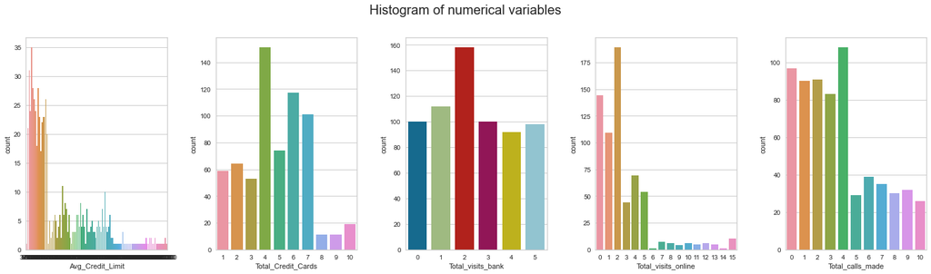

```python
fig, axes = plt.subplots(1, 5,  figsize=(20, 6))
fig.suptitle('Histogram of numerical variables', fontsize=20)
counter = 0
for ii in range(5):
    sns.countplot(ax=axes[ii],x=df[all_col[counter]])
    counter = counter+1

fig.tight_layout(pad=2.0)
```

# Observations

- Number of calls seems to be high compared to bank visit and online visits
- Many users have 4 number credit cards and second higest counts are 6 & 7
- quite number >=100 of customers are not using any of the channels bank visit, online or calls

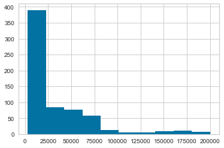

```python
df['Avg_Credit_Limit'].hist()
```

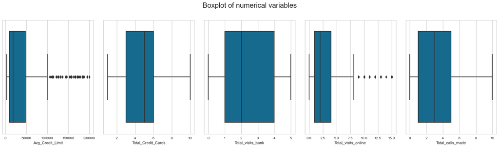

```python
fig, axes = plt.subplots(1, 5,  figsize=(20, 6))
fig.suptitle('Boxplot of numerical variables', fontsize=20)
counter = 0
for ii in range(5):
    sns.boxplot(ax=axes[ii],x=df[all_col[counter]])
    counter = counter+1

fig.tight_layout(pad=2.0)
```

# Bivariate Analysis

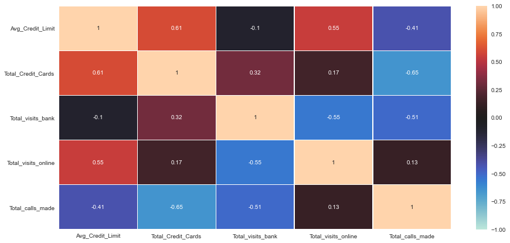

```python
plt.figure(figsize=(15,7))

sns.heatmap(df[all_col].corr(),
            annot=True,
            linewidths=0.5,vmin=-1,vmax=1,
            center=0,
            cbar=True,)

plt.show()
```

# Observations

# Pair Plot

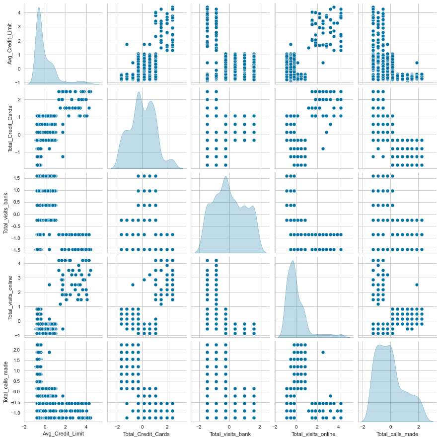

```python
cdataattr=df.iloc[:,:]
cdataScaled=cdataattr.apply(zscore)
sns.pairplot(cdataScaled,diag_kind='kde')
```

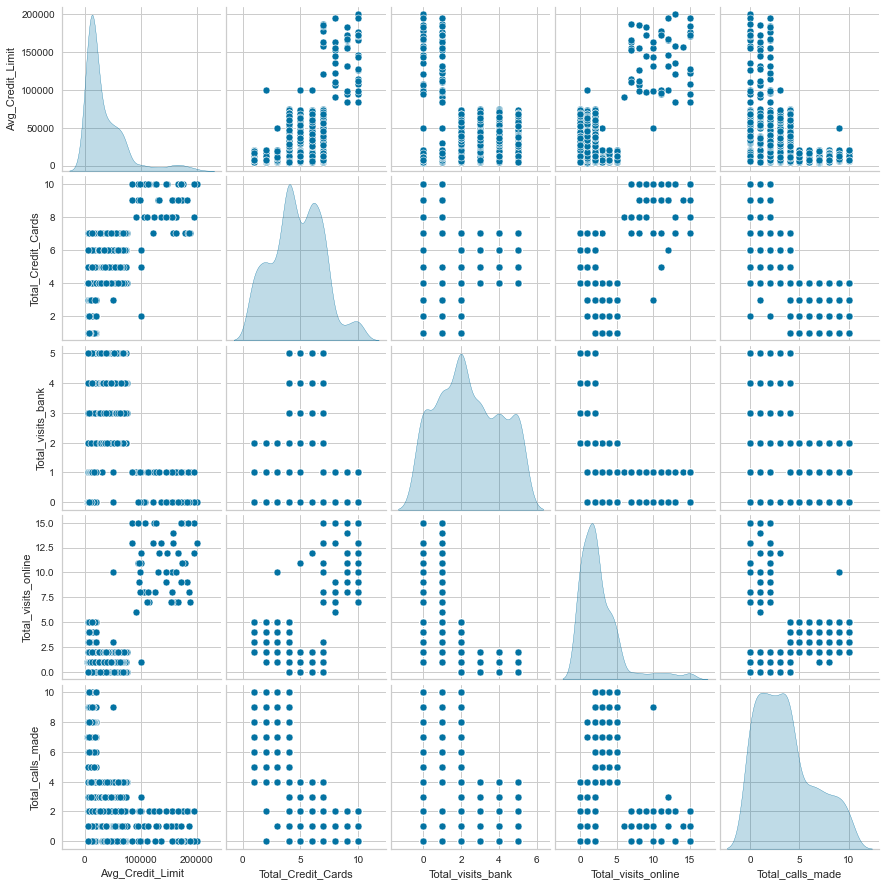

```python
sns.pairplot(df[all_col],diag_kind="kde")
```

# Kmeans

```
- Apply K-means (5marks)
- Elbow curve (3 marks)
- Silhouette Score ( 2 marks)
- figure out appropriate number of cluster (5 marks)
```

```python
# Scaling the data set before clustering
scaler=StandardScaler()
subset=df[all_col].copy()
subset_scaled=scaler.fit_transform(subset)
```

```python
#Creating a dataframe from the scaled data above
subset_scaled_df=pd.DataFrame(subset_scaled,columns=subset.columns)
```

```
Number of Clusters: 1 	Average Distortion: 2.0069222262503614
Number of Clusters: 2 	Average Distortion: 1.4571553548514269
Number of Clusters: 3 	Average Distortion: 1.1466276549150365
Number of Clusters: 4 	Average Distortion: 1.0463825294774465
Number of Clusters: 5 	Average Distortion: 0.9907072114489897
Number of Clusters: 6 	Average Distortion: 0.9430843103448057
Number of Clusters: 7 	Average Distortion: 0.9095661498049182
Number of Clusters: 8 	Average Distortion: 0.8901576204641674
```

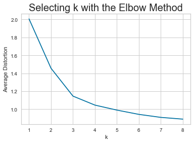

```python
clusters=range(1,9)
meanDistortions=[]

for k in clusters:
    model=KMeans(n_clusters=k)
    model.fit(subset_scaled_df)
    prediction=model.predict(subset_scaled_df)
    distortion=sum(np.min(cdist(subset_scaled_df, model.cluster_centers_, 'euclidean'), axis=1)) / subset_scaled_df.shape[0]

    meanDistortions.append(distortion)

    print('Number of Clusters:', k, '\tAverage Distortion:', distortion)

plt.plot(clusters, meanDistortions, 'bx-')
plt.xlabel('k')
plt.ylabel('Average Distortion')
plt.title('Selecting k with the Elbow Method', fontsize=20)
```

# Observation

The appropriate K values could be 3 or 4. Lets check 3 and 4 cluster and also silhoutee values

```python
sil_score = []
cluster_list = list(range(2,10))
for n_clusters in cluster_list:
    clusterer = KMeans(n_clusters=n_clusters)
    preds = clusterer.fit_predict((subset_scaled_df))
    #centers = clusterer.cluster_centers_
    score = silhouette_score(subset_scaled_df, preds)
    sil_score.append(score)
    print("For n_clusters = {}, silhouette score is {})".format(n_clusters, score))
```

```
For n_clusters = 2, silhouette score is 0.41842496663215445)
For n_clusters = 3, silhouette score is 0.5157182558881063)
For n_clusters = 4, silhouette score is 0.3556670619372605)
For n_clusters = 5, silhouette score is 0.2726698397729061)
For n_clusters = 6, silhouette score is 0.2555318695656245)
For n_clusters = 7, silhouette score is 0.24863099909417322)
For n_clusters = 8, silhouette score is 0.22656938373033814)
For n_clusters = 9, silhouette score is 0.2172133671138192)
```

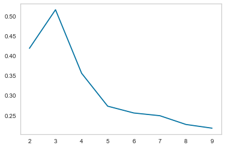

```python
plt.plot(cluster_list,sil_score)
plt.grid()
```

# Observations

From this score, it seems 3 is the good value for K

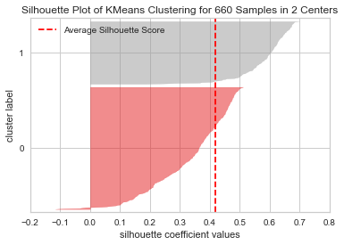

```python
#Finding optimal no. of clusters with silhouette coefficients
visualizer = SilhouetteVisualizer(KMeans(2, random_state = 1))
visualizer.fit(subset_scaled_df)
visualizer.show()
```

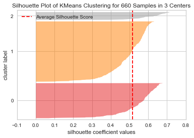

```python
#Finding optimal no. of clusters with silhouette coefficients
visualizer = SilhouetteVisualizer(KMeans(3, random_state = 1))
visualizer.fit(subset_scaled_df)
visualizer.show()
```

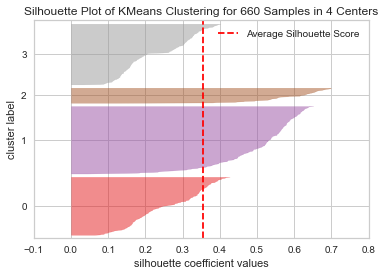

```python
#Finding optimal no. of clusters with silhouette coefficients
visualizer = SilhouetteVisualizer(KMeans(4, random_state = 1))
visualizer.fit(subset_scaled_df)
visualizer.show()
```

Lets take 3 as appropriate number based on silhoutte score and elbow bend

```python
kmeans = KMeans(n_clusters=3, random_state=0)
kmeans.fit(subset_scaled_df)
```

```
KMeans(n_clusters=3, random_state=0)
```

```python
df['K_means_segments'] = kmeans.labels_
```

```python
cluster_profile = df.groupby('K_means_segments').mean()
```

```python
cluster_profile['count_in_each_segment'] = df.groupby('K_means_segments')['Total_Credit_Cards'].count().values
```

```python
cluster_profile
```

| K_means_segments | Avg_Credit_Limit | Total_Credit_Cards | Total_visits_bank | Total_visits_online | Total_calls_made | count_in_each_segment |
| --- | --- | --- | --- | --- | --- | --- |
| 0 | 33782.383420 | 5.515544 | 3.489637 | 0.981865 | 2.000000 | 386 |
| 1 | 12174.107143 | 2.410714 | 0.933036 | 3.553571 | 6.870536 | 224 |
| 2 | 141040.000000 | 8.740000 | 0.600000 | 10.900000 | 1.080000 | 50 |

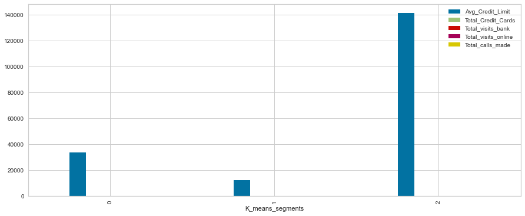

```python
df.groupby('K_means_segments').mean().plot.bar(figsize=(15,6))
```

```python
# just taking columns with o to 10 numeric values to check the bar chart. Credit limit has high range of values different than other columns
df_t = df.iloc[:,1:]
df_t.head()
```

|  | Total_Credit_Cards | Total_visits_bank | Total_visits_online | Total_calls_made | K_means_segments |
| --- | --- | --- | --- | --- | --- |
| 0 | 2 | 1 | 1 | 0 | 0 |
| 1 | 3 | 0 | 10 | 9 | 1 |
| 2 | 7 | 1 | 3 | 4 | 0 |
| 3 | 5 | 1 | 1 | 4 | 0 |
| 4 | 6 | 0 | 12 | 3 | 2 |

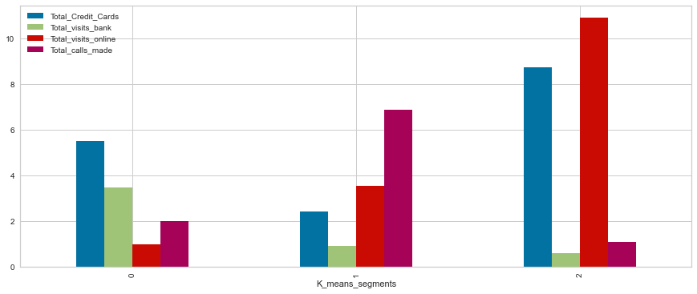

```python
df_t.groupby('K_means_segments').mean().plot.bar(figsize=(15,6))
```

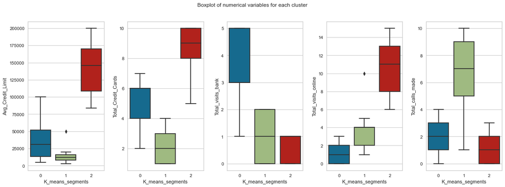

```python
fig, axes = plt.subplots(1, 5,  figsize=(16, 6))
fig.suptitle('Boxplot of numerical variables for each cluster')
counter = 0
for ii in range(5):
    sns.boxplot(ax=axes[ii],y=df[all_col[counter]],x=df['K_means_segments'])
    counter = counter+1

fig.tight_layout(pad=2.0)
```

# Observations

Cluster 0

- Average credit limit is medium
- Total number credit is above 5
- Total bank visits is high
- Online visits is low
- Phone calls is medium

Cluster 1

- Average credit limit is low (below 15k)
- Total number credit is less than 4, 2 to 3 cards
- Total bank visits is low
- Online visits is medium
- Phone calls is high

Cluster 2

- Average credit limit is high
- Total number credit is high
- Total bank visits is low
- Online visits is high
- Phone calls is low

# Try 4 cluster and check the distribution. As per score its not best k, but wanted to check because of the visulalizer and data distribution

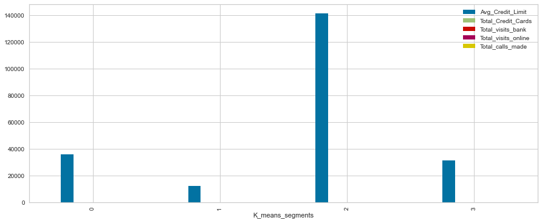

```python
kmeans = KMeans(n_clusters=4, random_state=0)
kmeans.fit(subset_scaled_df)
df['K_means_segments'] = kmeans.labels_
cluster_profile_4 = df.groupby('K_means_segments').mean()
df.groupby('K_means_segments').mean().plot.bar(figsize=(15,6))
```

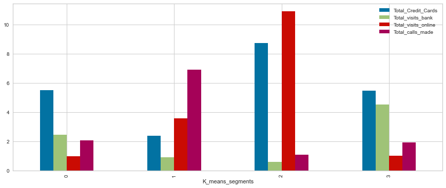

```python
df_t = df.iloc[:,1:]
df_t.groupby('K_means_segments').mean().plot.bar(figsize=(15,6))
```

# Observation

# Hierarchical Clustering

- Apply Hierarchical clustering with different linkage methods - Plot dendrograms - Choose appropriate number of cluster (15)

```python
# Just taking new copy of original dataset for hierarchical approach, old dataframe has been modified for k means
h_df = cdata.copy()
h_df.drop('Sl_No',axis=1,inplace=True)
h_df.drop('Customer Key',axis=1,inplace=True)
```

```python
h_df.head()
```

|  | Avg_Credit_Limit | Total_Credit_Cards | Total_visits_bank | Total_visits_online | Total_calls_made |
| --- | --- | --- | --- | --- | --- |
| 0 | 100000 | 2 | 1 | 1 | 0 |
| 1 | 50000 | 3 | 0 | 10 | 9 |
| 2 | 50000 | 7 | 1 | 3 | 4 |
| 3 | 30000 | 5 | 1 | 1 | 4 |
| 4 | 100000 | 6 | 0 | 12 | 3 |

```python
# Standardize the data
#method 1 apply zscore
from scipy.stats import zscore
h_df_z = h_df.apply(zscore)
```

```python
h_df_z.head()
```

|  | Avg_Credit_Limit | Total_Credit_Cards | Total_visits_bank | Total_visits_online | Total_calls_made |
| --- | --- | --- | --- | --- | --- |
| 0 | 1.740187 | -1.249225 | -0.860451 | -0.547490 | -1.251537 |
| 1 | 0.410293 | -0.787585 | -1.473731 | 2.520519 | 1.891859 |
| 2 | 0.410293 | 1.058973 | -0.860451 | 0.134290 | 0.145528 |
| 3 | -0.121665 | 0.135694 | -0.860451 | -0.547490 | 0.145528 |
| 4 | 1.740187 | 0.597334 | -1.473731 | 3.202298 | -0.203739 |

```python
# or
# method 2
# you could use any
from sklearn.preprocessing import StandardScaler
import numpy as np
sc = StandardScaler()
h_df_STD = pd.DataFrame(sc.fit_transform(h_df),columns=h_df.columns)
```

```python
h_df_STD.head()
```

|  | Avg_Credit_Limit | Total_Credit_Cards | Total_visits_bank | Total_visits_online | Total_calls_made |
| --- | --- | --- | --- | --- | --- |
| 0 | 1.740187 | -1.249225 | -0.860451 | -0.547490 | -1.251537 |
| 1 | 0.410293 | -0.787585 | -1.473731 | 2.520519 | 1.891859 |
| 2 | 0.410293 | 1.058973 | -0.860451 | 0.134290 | 0.145528 |
| 3 | -0.121665 | 0.135694 | -0.860451 | -0.547490 | 0.145528 |
| 4 | 1.740187 | 0.597334 | -1.473731 | 3.202298 | -0.203739 |

```python
# Find linkage matrix, here i am using Ward linkage
#### generate the linkage matrix
from scipy.cluster.hierarchy import dendrogram, linkage
Z = linkage(h_df_STD, 'ward', metric='euclidean')
Z.shape
```

```
(659, 4)
```

```python
Z[:]
```

```
array([[ 464.        ,  497.        ,    0.        ,    2.        ],
       [ 425.        ,  455.        ,    0.        ,    2.        ],
       [ 250.        ,  361.        ,    0.        ,    2.        ],
       ...,
       [1313.        , 1314.        ,   16.84480374,  385.        ],
       [1311.        , 1316.        ,   47.06715339,  435.        ],
       [1315.        , 1317.        ,   50.16298666,  660.        ]])
```

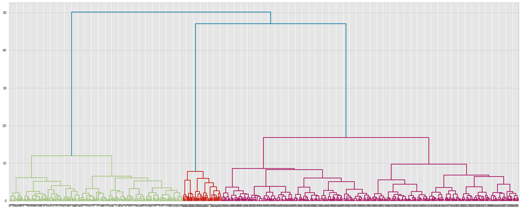

```python
# Plot the dendrogram for the consolidated dataframe
plt.figure(figsize=(25, 10))
dendrogram(Z)
plt.show()
```

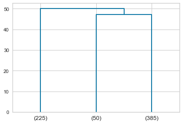

```python
# Use truncate_mode='lastp' attribute in dendrogram function to arrive at dendrogram
dendrogram(
    Z,
    truncate_mode='lastp',  # show only the last p merged clusters
    p=3,  # show only the last p merged clusters
)
plt.show()
```

```python
# Use this distance measure(max_d) and fcluster function to cluster the data into 3 different groups
max_d = 20
from scipy.cluster.hierarchy import fcluster
from scipy.spatial.distance import pdist
clusters = fcluster(Z, max_d, criterion='distance')
clusters
```

```
array([3, 1, 3, 3, 2, 1, 2, 1, 1, 1, 1, 1, 1, 1, 1, 1, 1, 1, 1, 1, 1, 1,
       1, 1, 1, 1, 1, 1, 1, 1, 1, 1, 1, 1, 1, 1, 1, 1, 1, 1, 1, 1, 1, 1,
       1, 1, 1, 1, 1, 1, 1, 1, 1, 1, 1, 1, 1, 1, 1, 1, 1, 1, 1, 1, 1, 1,
       1, 1, 1, 1, 1, 1, 1, 1, 1, 1, 1, 1, 1, 1, 1, 1, 1, 1, 1, 1, 1, 1,
       1, 1, 1, 1, 1, 1, 1, 1, 1, 1, 1, 1, 1, 1, 1, 1, 1, 1, 1, 1, 1, 1,
       1, 1, 1, 1, 1, 1, 1, 1, 1, 1, 1, 1, 1, 1, 1, 1, 1, 1, 1, 1, 1, 1,
       1, 1, 1, 1, 1, 1, 1, 1, 1, 1, 1, 1, 1, 1, 1, 1, 1, 1, 1, 1, 1, 1,
       1, 1, 1, 1, 1, 1, 1, 1, 1, 1, 1, 1, 1, 1, 1, 1, 1, 1, 1, 1, 1, 1,
       1, 1, 1, 1, 1, 1, 1, 1, 1, 1, 1, 1, 1, 1, 1, 1, 1, 1, 1, 1, 1, 1,
       1, 1, 1, 1, 1, 1, 1, 1, 1, 1, 1, 1, 1, 1, 1, 1, 1, 1, 1, 1, 1, 1,
       1, 1, 1, 1, 1, 1, 1, 1, 3, 3, 3, 3, 3, 3, 3, 3, 3, 3, 3, 3, 3, 3,
       3, 3, 3, 3, 3, 3, 3, 3, 3, 3, 3, 3, 3, 3, 3, 3, 3, 3, 3, 3, 3, 3,
       3, 3, 3, 3, 3, 3, 3, 3, 3, 3, 3, 3, 3, 3, 3, 3, 3, 3, 3, 3, 3, 3,
       3, 3, 1, 3, 3, 3, 3, 3, 3, 3, 3, 3, 3, 3, 3, 3, 3, 3, 3, 3, 3, 3,
       3, 3, 3, 3, 3, 1, 3, 3, 3, 3, 3, 3, 3, 3, 3, 3, 3, 3, 3, 3, 3, 3,
```

[output cut: 16 more lines]

```python
# find cophenetic distance
from scipy.cluster.hierarchy import single, cophenet
c,coph_distance = cophenet(Z, pdist(h_df_STD))
c
```

```
0.7415156284827493
```

```python
# Calculate Avg Silhoutte Score

from sklearn.metrics import silhouette_score
silhouette_score(h_df_STD,clusters)
```

```
0.5147639589977819
```

# Final dendogram with 'ward linkage'

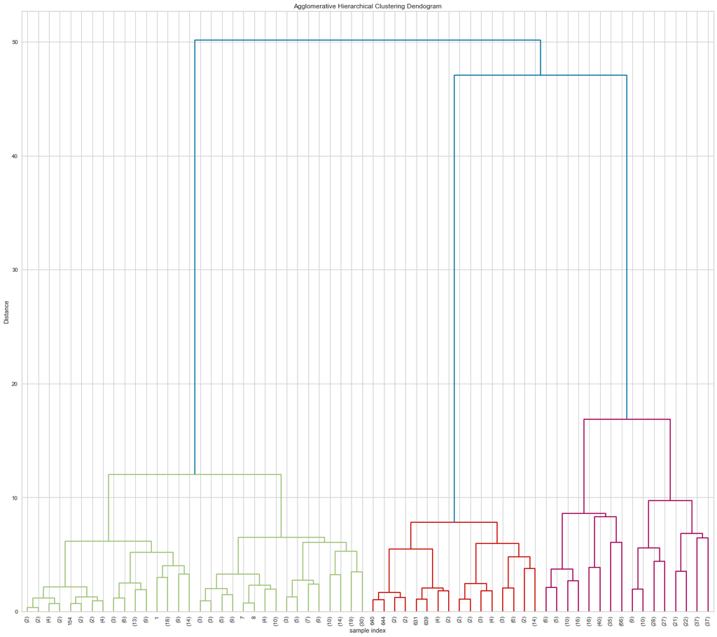

```python
from scipy.cluster.hierarchy import dendrogram, linkage
from scipy.spatial.distance import pdist
import matplotlib.pyplot as plt
plt.figure(figsize=(18, 16))
plt.title('Agglomerative Hierarchical Clustering Dendogram')
plt.xlabel('sample index')
plt.ylabel('Distance')
Z = linkage(h_df_STD, 'ward')
dendrogram(Z,leaf_rotation=90.0,p=5,color_threshold=20,leaf_font_size=10,truncate_mode='level')
plt.tight_layout()
```

# Observations

- Dendograms shows the 3 clusters above maxd is 20
- Cophentic score is 0.74 - seems to be good score
- Silhoutte score is 0.51 , that mathches the score which in previous silhoutte score which we used to find the Kmeans.Silhoutte is better when close to 1. Here its 0.51 not a bad score

```python
from sklearn.cluster import AgglomerativeClustering
```

```python
model = AgglomerativeClustering(n_clusters=3, affinity='euclidean',  linkage='ward')
```

```python
model.fit(h_df_STD)
```

```
AgglomerativeClustering(n_clusters=3)
```

```python
h_df['labels'] = model.labels_
h_df.head(10)
```

|  | Avg_Credit_Limit | Total_Credit_Cards | Total_visits_bank | Total_visits_online | Total_calls_made | labels |
| --- | --- | --- | --- | --- | --- | --- |
| 0 | 100000 | 2 | 1 | 1 | 0 | 0 |
| 1 | 50000 | 3 | 0 | 10 | 9 | 1 |
| 2 | 50000 | 7 | 1 | 3 | 4 | 0 |
| 3 | 30000 | 5 | 1 | 1 | 4 | 0 |
| 4 | 100000 | 6 | 0 | 12 | 3 | 2 |
| 5 | 20000 | 3 | 0 | 1 | 8 | 1 |
| 6 | 100000 | 5 | 0 | 11 | 2 | 2 |
| 7 | 15000 | 3 | 0 | 1 | 1 | 1 |
| 8 | 5000 | 2 | 0 | 2 | 2 | 1 |
| 9 | 3000 | 4 | 0 | 1 | 7 | 1 |

```python
h_df['labels'].value_counts()
```

```
0    385
1    225
2     50
Name: labels, dtype: int64
```

```python
cluster_profile_h = h_df.groupby('labels').mean()
cluster_profile_h['count_in_each_segment'] = h_df.groupby('labels')['Total_Credit_Cards'].count().values
cluster_profile_h
```

| labels | Avg_Credit_Limit | Total_Credit_Cards | Total_visits_bank | Total_visits_online | Total_calls_made | count_in_each_segment |
| --- | --- | --- | --- | --- | --- | --- |
| 0 | 33851.948052 | 5.516883 | 3.493506 | 0.979221 | 1.994805 | 385 |
| 1 | 12151.111111 | 2.422222 | 0.937778 | 3.546667 | 6.857778 | 225 |
| 2 | 141040.000000 | 8.740000 | 0.600000 | 10.900000 | 1.080000 | 50 |

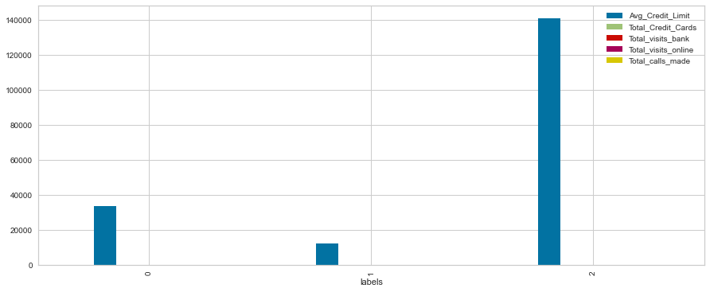

```python
h_df.groupby('labels').mean().plot.bar(figsize=(15,6))
```

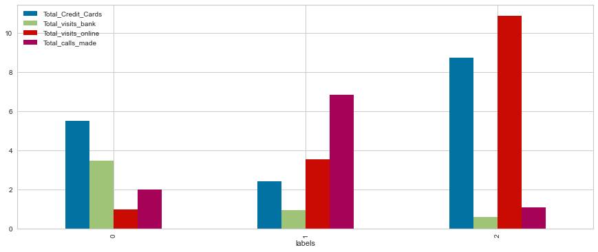

```python
df_h1 = h_df.iloc[:,1:]
df_h1.groupby('labels').mean().plot.bar(figsize=(15,6))
```

# Clusters Comparison

```
- Compare cluster K-means clusters and Hierarchical clusters (2 marks)
- Perform cluster profiling (2 marks)
- Derive Insights (4 marks)
```

```python
#k means cluster profile
cluster_profile
```

| K_means_segments | Avg_Credit_Limit | Total_Credit_Cards | Total_visits_bank | Total_visits_online | Total_calls_made | count_in_each_segment |
| --- | --- | --- | --- | --- | --- | --- |
| 0 | 33782.383420 | 5.515544 | 3.489637 | 0.981865 | 2.000000 | 386 |
| 1 | 12174.107143 | 2.410714 | 0.933036 | 3.553571 | 6.870536 | 224 |
| 2 | 141040.000000 | 8.740000 | 0.600000 | 10.900000 | 1.080000 | 50 |

```python
#hierarchical cluster profile
cluster_profile_h
```

| labels | Avg_Credit_Limit | Total_Credit_Cards | Total_visits_bank | Total_visits_online | Total_calls_made | count_in_each_segment |
| --- | --- | --- | --- | --- | --- | --- |
| 0 | 33851.948052 | 5.516883 | 3.493506 | 0.979221 | 1.994805 | 385 |
| 1 | 12151.111111 | 2.422222 | 0.937778 | 3.546667 | 6.857778 | 225 |
| 2 | 141040.000000 | 8.740000 | 0.600000 | 10.900000 | 1.080000 | 50 |

# Observation

- The count in segement from Kmeans cluster and Hierarchical cluster matches, just one data difference in segement 0 and Segment 1
- The variable means values are same from both clusters
- Cophentic score is good for 3 clusters and Silheutto score also matches

  Using both the technique we arrived at 3 clusters with good cophenetic and Silheutte score. Able to group the customer and identify the customer segments

# Conclusion and Business Recommendation Business conclusion and Recommendation - (7 marks) 7

How many different segments of customers are there? How are these segments different from each other? What are your recommendations to the bank on how to better market to and service these customers?

# Business Recommendations

- Cluster 0 customers are frequent bank visitors

Recommendation: Bank can encourage and educate them to use online services. Bank will need to concentrate more on marketing and Advertisements about their online channels. When customers visit the bank bank can upsell their new products

- Cluster 1 customers are using Phone channels and does not more cards

Recommendation: Bank will need to focus on improving their online and look for any technical issues, work with their IT department focus to improve the online channels and try to reduce the number of phone calls and these customers mighe be facing technical issues. Bank can also train their agent to give product recommendation while addressing the customer request over phone

- Cluster 2 online customers,

Recommendation: Bank has to focus on more marketing and promotional banners on their online and also bank can more channels.